# Classification - Part II

Yujia Pan (yujiap@umich.edu)

Big Data Summer Institute 2018

University of Michigan

# Today

1. Review
2. Finish up Random Forests
3. "To ponder"
4. Classification in practice
   - How to perform a classification analysis: gene expression data
   - How to choose a classifier: when might we want to use each of the classifiers we've learned about?

# Review

- Assume there is an underlying function $f$ relating predictor variables (features) to the response (class).
- $f$ unknown, so need to estimate it from data.
  - parametric methods
    - assume the shape of $f$, so that estimating of $f$ is equivalent to estimating a set of parameters
    - e.g. LDA (normality, equal feature variances b/w classes)
    - e.g. Logistic regression (log-odds ratio of $P(Y=j|X=\widetilde{x})$ is a linear function of $\widetilde{x}$)
    - e.g. QDA
  - nonparametric methods
    - e.g. kNN
    - e.g. Random Forests

# Review (cont'd)

- The optimal classifier computes $P(Y=j|X=\widetilde{x})$ for all classes $j$ and classifies a test observation to the class giving the largest conditional probability.
- Many classifiers try to estimate $P(Y=j|X=\widetilde{x})$ to classify a test observation
  - **kNN** uses (training set) neighbors of the the test observation to estimate $P(Y=j|X=\widetilde{x})$
  - **Logistic regression** tries to model the log odds of $P(Y=j|X=\widetilde{x})$ as a function of $X$
  - **LDA, QDA** model the $P(X| Y=j) \sim N(\mu_j ,\sigma^2)$ and uses Bayes' rule to flip this probability into $P(Y=j|X=\widetilde{x})$
- Linear classifiers define linear decision boundaries, nonlinear classifiers define nonlinear decision boundaries

# Revisiting Random Forests

## How to grow a decision tree?

- At every step, we select the rule that maximizes gain in "purity" (as measured by Gini index or entropy)
- This is a greedy approach
- Stop growing when splitting the tree further does not result in significant increase in purity

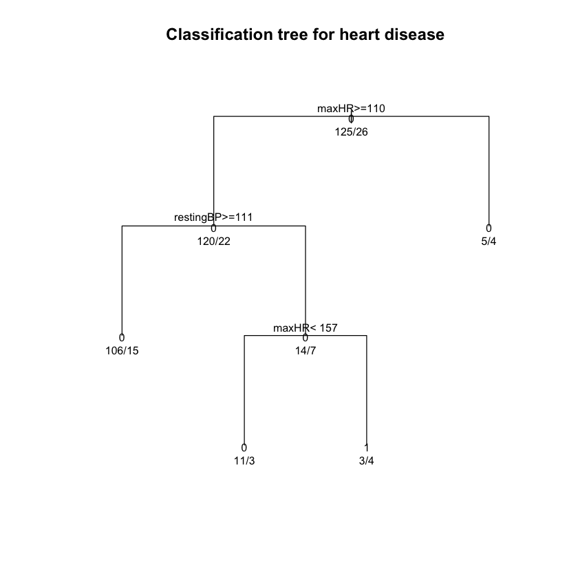

```r
heart.data <- read.csv("processed.cleveland.data", header = FALSE)
names(heart.data) <- c("age", "sex", "cp", "trestbps", "chol", "fbs", "restecg", "thalach", "exang", "oldpeak", "slope", "ca", "thal", "num")

X = heart.data[, c("trestbps", "thalach")]
Y = heart.data[, "num"]

# rename features
colnames(X) = c("restingBP", "maxHR")

# randomly split into training and test sets
n = nrow(X)
train.ix = sample(1:n, n/2)

Xtrain = X[train.ix,]
Ytrain = Y[train.ix]
Xtest = X[-train.ix,]
Ytest = Y[-train.ix]

# recode response from -1,1 to 0,1 (probabilities!)
Ytrain = ifelse(Ytrain==1, 1, 0)
Ytest = ifelse(Ytest==1, 1, 0)

# assemble dataframes
train = data.frame(Xtrain, Ytrain)
test = data.frame(Xtest, Ytest)

library(rpart)
ct = rpart(Ytrain ~., data=train, method="class", parms=list(split="gini") , control=c(maxdepth=3))
plot(ct, uniform=TRUE, main="Classification tree for heart disease", margin=0.1)
text(ct, use.n=TRUE, all=TRUE, cex=.8)
```

## Advantages of decision trees

- **Interpretable** (easy for humans to understand)
- Can handle **categorical and continuous** predictors without need for dummy variables
  - e.g. in linear regression, we can't directly use `eyecolor` = ("black", "brown", "brown", $\ldots$ , "green") as a predictor, but with trees we can

## Disadvantages of decision trees

- Not very **robust**
- If you want to incorporate new data, you have to train the decision tree all over again
- Generally very poor classification performance

## Random Forests

- Is a "strength in numbers" approach to using decision trees (**ensemble method**)
- Takes random subset of the training data and a random subset of features and uses it to grow a decision tree.
- Repeats this many times, resulting in many trees
- "Combines" the trees

See yesterday's slides ($\texttt{bdsi-classification-1.html}$) for

- mathematical details
- some example code

# To ponder...

**We saw that nonlinear classifiers produce more flexible classification boundaries. Why might we still want to use a linear classifier over a nonlinear classifier?**

- Nonlinear classifiers may **overfit** the training data and fail to generalize well, leading to poor predictive accuracy on the test data. Linear classifiers define linear decision boundaries (hyperplanes that separate observations into one class or the other), and may resist overfitting.
- Another way to understand overfitting: low bias at the expense of high variance

[figure not shown]

- If your classifier has a low training error rate but high test error rate, overfitting may be to blame

# To ponder...

**Today we didn't discuss the actual datasets you'll be working with. It turns out that some of these classifiers don't work well when applied to those datasets.**

- **Which ones?**
- **Can you think of some reasons why?**

In your datasets, the number of features ($p$) is much larger than the number of training observations ($n$). We say this data is **high dimensional**.

Many traditional statistical methods, including almost all the classifiers we covered, "do not work" on high dimensional data.

## Why not?

With high dimensional data:

1. We tend to **overfit** classifiers
2. Parameter estimation may be an **ill-posed** problem

### Overfitting

- When the number of features is large relative to the number of training observations, our (training) observations are basically a few points sparsely populating some very large feature space
- Since there's more space between the data points, it's easy to find a surface that perfectly separates them
- But this surface is actually really complicated "when we look at it in 2D" - overfitting!
- This is **the curse of dimensionality**

### Ill-posed parameter estimation problems

- the number of parameters we need to estimate outnumbers the number of training observations
- e.g. LDA requires us to estimate $\pi_0, \pi_1, \Sigma, {\mu_1}, \mu_2$. The covariance matrix $\Sigma$ alone is $p \times p$. If we have less than $p$ data points, then the problem of estimating $\Sigma$ is ill-posed!
- Suppose we only have one predictor. LDA assumes that an observation $X \in \mathbb{R}$ coming from class $j$ is distributed $N(\mu_j, \sigma^2)$.
- If we have $p$ predictors, LDA assumes that an observation $X \in \mathbb{R}^p$ coming from class $j$ is distributed according to $\mathcal{N}_p(\mu_j, \Sigma)$ (**multivariate normal**)
- This is the analogue of the $N(\mu, \sigma^2)$ density in $p$-dimensions: $$f(x) = \frac{1}{(2\pi)^{p/2}~|\Sigma|^{1/2}} \exp \left( -\frac 12 (x-\mu)^\top \Sigma^{-1} (x-\mu) \right)$$
  - $\mu_j = E(X)$ is the mean of $X$, a $p$-dimensional vector
  - $\Sigma = cov(X)$ is the $p \times p$ covariance matrix of $X$
- The estimates for $\mu, \Sigma$ are analogues of our familiar one-dimensional estimates.
- $\Sigma$ is $p \times p$, so this already gives us $p^2$ parameters we need to estimate.
- Since the number of training observations is less than $p$, we have more parameters to estimate than we do data points! This is what we mean when we say a parameter estimation problem (here, for $\Sigma$) is **ill-posed**.

```r
# make up some training data; not important what it is, just note that p > no. of training observations
Xtrain_sim = matrix(rnorm(10*4), 4, 10)
print(dim(Xtrain_sim))
```

```
[1]  4 10
```

```r
Sigmahat_sim = cov(Xtrain_sim)
solve(Sigmahat_sim)
```

```
Error in solve.default(Sigmahat_sim): system is computationally singular: reciprocal condition number = 2.4689e-18
Traceback:

1. solve(Sigmahat_sim)
2. solve.default(Sigmahat_sim)
```

## What can we do?

We can alleviate these problems with

1. **Feature selection**: Judiciously select a subset of features to use so that the number of features is less than the number of training observations.
1. **Regularized methods**: Regularized methods use additional information or make additional assumptions in order to reduce overfitting and/or overcome ill-posed parameter estimation problems
   - e.g. impose penalties on objective function when doing parameter estimation
   - Penalties are controlled by **regularization parameters**, which are generally selected via cross-validation

# Feature selection for classification

- Some classification methods do this automatically, as part of the method (**"embedded methods"**)
  - e.g. Random Forests
  - $\times$ May not be as transparent, since it is happening "inside" the classifier
  - $\checkmark$ Easy for human user
- Sometimes you do this before applying a classifier (**"filter methods"**)
  - e.g. select genes which are most "different" between the two classes, then apply any classifier you wish
  - We will cover this by example when we walkthrough a classification analysis.
  - $\times$ Does not consider correlations between variables, so may select redundant variables (often OK - why?)
  - $\checkmark$ Tend to be robust, computationally efficient
- Is performed using the **training set** only!</span>

# Regularized methods

We'll cover:

1. Diagonal LDA
2. Regularized LDA
3. glmnet

The first two are regularized versions of LDA. The last is a regularized version of logistic regression.

## Diagonal LDA (DLDA)

- **Assume that features are independent, conditional on class**
  - e.g. Given that someone has heart disease, their resting blood pressure is independent of their cholesterol level, max heart rate, etc.
  - This is equivalent to assuming that **$\Sigma$ is diagonal** (why?)</span>
- This assumption corrects ill-posedness by greatly reducing the number of parameters we have to estimate (why?)
  - `cov(X)` will be a better estimate of $\Sigma$ (it will now be invertible)
  - But `cov(X)` may still not be a good estimate of $\Sigma$
    - Solution: DLDA with "top 10 genes" (more on what "top 10 means later")

## Regularized LDA

- "Nudge" the covariance matrix
  - Use `cov(X)` + $\alpha I$ instead of `cov(X)` as our estimate of $\Sigma$
- "Nudging" corrects ill-posedness of estimating $\Sigma$, since `cov(X)`+ $\alpha I$ is always invertible.

## Regularized logistic regression (glmnet)

- Incorporate "penalities" into parameter estimation process
- These penalties make parameter estimates slightly biased, but greatly reduce their variance, so overall, parameter estimates are improved

# How to perform a classification analysis

1. Preprocessing (e.g. cleaning, transform, handling missing values)
2. Feature selection (optional)
3. Train classifier
4. Evaluate/test classifier

Train a classifier on a training set , evaluate it on a test set .

We have the class label of every observation in the training and every observation in the test set.

The practical value of building a good classifier is that we can deploy it and use it in real life, on observations we have no class labels for. A classifier with low error rate on the test set (observations we're *pretending* we've never seen before) hopefully also has low error rate on observations it truly has never seen before.

## Our dataset

We will walk through steps 2,3, and 4 using a high-dimensional gene expression dataset similar to what you will be working with.

```r
# get expression data for Drug 1014
expression.data = readRDS("expression for 1014.rds")
effectiveness = readRDS("classes for 1014.rds")
```

```r
# get to know your data
dim(expression.data)
dim(effectiveness)
```

1. 246

2. 17737

1. 246

2. 2

```r
expression.data[1:3,1:5]
```

|  | ENSG00000000003 | ENSG00000000005 | ENSG00000000419 | ENSG00000000457 | ENSG00000000460 |
| --- | --- | --- | --- | --- | --- |
| 683667 | 7.780713 | 2.753253 | 9.960137 | 4.351073 | 3.716740 |
| 684055 | 8.690198 | 3.091473 | 9.992487 | 4.572198 | 3.333385 |
| 684059 | 8.333466 | 3.966757 | 9.793991 | 3.976923 | 3.505669 |

```r
effectiveness[1:3,]
```

|  | CL | EFFECT |
| --- | --- | --- |
| 30 | 683667 | FALSE |
| 52 | 684055 | FALSE |
| 89 | 684059 | FALSE |

```r
# how many observations do we have of each class
table(effectiveness$EFFECT)
```

```
FALSE  TRUE
  111   135
```

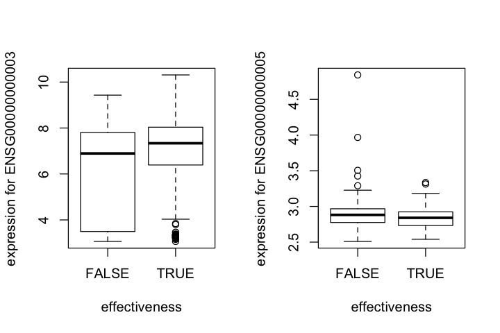

```r
# visualize your data! here we use boxplots, but there are many other plots you could make
options(repr.plot.width=6, repr.plot.height=4)
par(mfrow = c(1,2))
boxplot(expression.data$ENSG00000000003 ~ effectiveness$EFFECT, xlab="effectiveness",
       ylab="expression for ENSG00000000003")
boxplot(expression.data$ENSG00000000005 ~ effectiveness$EFFECT, xlab="effectiveness",
       ylab="expression for ENSG00000000005")
```

```r
# split into training and test sets
n = nrow(expression.data)
train.ix = sample(1:n, n/2)

expression.train = expression.data[train.ix,]
effective.train = effectiveness$EFFECT[train.ix]
expression.test = expression.data[-train.ix,]
effective.test = effectiveness$EFFECT[-train.ix]

dim(expression.train)
dim(expression.test)
expression.train[1:3,1:5]
expression.test[1:3,1:5]
```

1. 123

2. 17737

1. 123

2. 17737

|  | ENSG00000000003 | ENSG00000000005 | ENSG00000000419 | ENSG00000000457 | ENSG00000000460 |
| --- | --- | --- | --- | --- | --- |
| 1503365 | 8.631575 | 2.691465 | 10.403906 | 4.184282 | 3.638513 |
| 906870 | 5.445639 | 2.733892 | 9.736273 | 4.730063 | 3.785159 |
| 907795 | 8.116502 | 2.699422 | 9.683543 | 4.825148 | 3.513689 |

|  | ENSG00000000003 | ENSG00000000005 | ENSG00000000419 | ENSG00000000457 | ENSG00000000460 |
| --- | --- | --- | --- | --- | --- |
| 683667 | 7.780713 | 2.753253 | 9.960137 | 4.351073 | 3.716740 |
| 684055 | 8.690198 | 3.091473 | 9.992487 | 4.572198 | 3.333385 |
| 684059 | 8.333466 | 3.966757 | 9.793991 | 3.976923 | 3.505669 |

## Feature selection: one method

- We might choose to select the 10 genes which are most differentially expressed between people for whom the drug was not effective ("nonresponders") and people for whom the drug was effective ("responders").
- "10 most differentially expressed genes" $\leftrightsquigarrow$ genes with 10 lowest p-values
- Use the training data to do compute p-values. Once you've identified the "top" genes, make sure to subset both training and test sets to these genes.
- Reminder: The only time you should touch the test data is at the very end, when you evaluate your classifier

```r
# get p-values and find out which genes yield the 10 smallest p-values
# ... your turn! ...
```

```r
# subset training and test sets to the selected genes
# your selected genes may be slightly different, since our training sets may differ!
selected = c(10850, 13962, 448, 1784, 2557, 6834, 1143, 4793, 5974, 10944)
Xtrain = expression.train[,selected]
Xtest = expression.test[,selected]
```

```r
# check that we subsetted correctly
Xtrain[1:3, 1:5]
Xtest[1:3,1:5]
```

|  | ENSG00000164733 | ENSG00000181381 | ENSG00000026508 | ENSG00000089327 | ENSG00000102265 |
| --- | --- | --- | --- | --- | --- |
| 1503365 | 9.400849 | 6.975650 | 7.763025 | 7.945949 | 8.116163 |
| 906870 | 8.802219 | 7.081204 | 9.602375 | 9.048608 | 8.860841 |
| 907795 | 9.502434 | 6.513742 | 6.761477 | 9.206552 | 8.812320 |

|  | ENSG00000164733 | ENSG00000181381 | ENSG00000026508 | ENSG00000089327 | ENSG00000102265 |
| --- | --- | --- | --- | --- | --- |
| 683667 | 10.173392 | 5.476169 | 3.436858 | 5.852062 | 9.180111 |
| 684055 | 8.587573 | 4.438306 | 3.231063 | 5.835459 | 9.244823 |
| 684059 | 8.373435 | 7.079048 | 3.354313 | 5.980766 | 10.397093 |

## Training a classifier

If your classifier involves tuning some parameters (e.g. choosing $k$ in kNN), do that at this stage. Tuning is a part of training.

Note: `lda_classifier` is like $\widehat{f}$

```r
library(MASS)
lda_classifier = lda(Xtrain, effective.train)
```

## Evaluating a classifier

- Using the previously trained classifier, **make predictions** for the test set.
  - In this step we take the $\widehat{f}$ estimated from the training set and applying it to the test set observations $\{ \widetilde{x}_1, \widetilde{x}_2, \ldots, \widetilde{x}_{\widetilde{n}}\}$
  - Note that we are not using the true class labels of the test observations, $\{ \widetilde{y}_1, \widetilde{y}_2, \ldots, \widetilde{y}_{\widetilde{n}}\}$
- Compare the predictions the classifier made for the test set observations to the true class labels of the test set observations and **compute test error rate (or accuracy rate)**.
  - i.e. compare $\{ \widehat{f}(\widetilde{x}_1), \widehat{f}(\widetilde{x}_2), \ldots, \widehat{f}(\widetilde{x}_{\widetilde{n}})\}$ to $\{ \widetilde{y}_1, \widetilde{y}_2, \ldots, \widetilde{y}_{\widetilde{n}}\}$

```r
# make predictions
pred_out = predict(lda_classifier, Xtest)
class_preds = pred_out$class
n_correct_preds = sum(effective.test==class_preds)
n_correct_preds
```

111

```r
acc_rate = n_correct_preds / length(class_preds)
acc_rate
```

0.902439024390244

- Other ways of quantifying a classifier's performance
  - sensitivity (true positive rate)
  - specificity (true negative rate)
  - ROC curve
- You will likely want to repeat this process and train several different classifiers to see which one gives the lowest error rate (best accuracy rate) on the test set.

# How to choose a classifier

- For hypothesis testing, we have many kinds of hypothesis tests...each suited for a particular situation.
  - e.g. paired t-test
- For classification, we have many kinds of classification methods...but it's not easy to say which classifiers will be good in any given situation
  - We don't know if parametric assumptions on $f$ hold (e.g. $f$ linear?)
  - Even if an assumption doesn't hold, we may still achieve good prediction performance by using it
    - e.g. DLDA often works well, even though the independence assumption is probably not true!
- In practice, we generally choose a classifier by training several different kinds of classifiers and picking the one that gives the smallest test error rate.